# Threat of Major Storms and Weather Events in the United States of America

Manuel A. Cerda R.

23 April 2016

# Synopsis

Storms and other severe weather events can cause both public health and economic problems for communities and municipalities. Many severe events can result in fatalities, injuries, and property damage, and preventing such outcomes to the extent possible is a key concern.

This project involves exploring the U.S. National Oceanic and Atmospheric Administration’s (NOAA) storm database. This database tracks characteristics of major storms and weather events in the United States, including when and where they occur, as well as estimates of any fatalities, injuries, and property damage.

## Data Source

The data for this assignment come in the form of a comma-separated-value file compressed via the bzip2 algorithm to reduce its size. You can download the file from the course web site:

- [Storm Data](https://d396qusza40orc.cloudfront.net/repdata%2Fdata%2FStormData.csv.bz2)

There is also some documentation of the database available. Here you will find how some of the variables are constructed/defined.

- National Weather Service [Storm Data Documentation](https://d396qusza40orc.cloudfront.net/repdata%2Fpeer2_doc%2Fpd01016005curr.pdf)
- National Climatic Data Center Storm Events [FAQ](https://d396qusza40orc.cloudfront.net/repdata%2Fpeer2_doc%2FNCDC%20Storm%20Events-FAQ%20Page.pdf)

The events in the database start in the year 1950 and end in November 2011. In the earlier years of the database there are generally fewer events recorded, most likely due to a lack of good records. More recent years should be considered more complete.

## Data Processing

```r
library(dplyr)
library(plyr)
library(data.table)
library(ggplot2)
library(maps)
library(mapproj)
```

```r
# Load the data after extracted from the compressed file
rawData <- read.csv(file.path(getwd(), "repdata-data-StormData.csv", fsep = .Platform$file.sep))
```

```r
# Separate the number of injuries by State
injuries <- subset(ddply(rawData, "STATE", summarise, injuries = sum(INJURIES)),
    STATE %in% state.abb)
injuries$region <- state.name[match(injuries$STATE, state.abb)]

# Separate the number of fatalities by State
fatalities <- subset(ddply(rawData, "STATE", summarise, fatalities = sum(FATALITIES)),
    STATE %in% state.abb)
fatalities$region <- state.name[match(fatalities$STATE, state.abb)]
```

```r
# Show summary of the observations
nrow(rawData)
```

```
## [1] 902297
```

```r
colnames(rawData)
```

```
##  [1] "STATE__"    "BGN_DATE"   "BGN_TIME"   "TIME_ZONE"  "COUNTY"
##  [6] "COUNTYNAME" "STATE"      "EVTYPE"     "BGN_RANGE"  "BGN_AZI"
## [11] "BGN_LOCATI" "END_DATE"   "END_TIME"   "COUNTY_END" "COUNTYENDN"
## [16] "END_RANGE"  "END_AZI"    "END_LOCATI" "LENGTH"     "WIDTH"
## [21] "F"          "MAG"        "FATALITIES" "INJURIES"   "PROPDMG"
## [26] "PROPDMGEXP" "CROPDMG"    "CROPDMGEXP" "WFO"        "STATEOFFIC"
## [31] "ZONENAMES"  "LATITUDE"   "LONGITUDE"  "LATITUDE_E" "LONGITUDE_"
## [36] "REMARKS"    "REFNUM"
```

```r
summary(injuries$injuries)
```

```
##    Min. 1st Qu.  Median    Mean 3rd Qu.    Max.
##    48.0   396.8  1620.0  2789.0  4310.0 17670.0
```

```r
summary(fatalities$fatalities)
```

```
##    Min. 1st Qu.  Median    Mean 3rd Qu.    Max.
##     7.0    72.5   171.0   296.7   398.0  1421.0
```

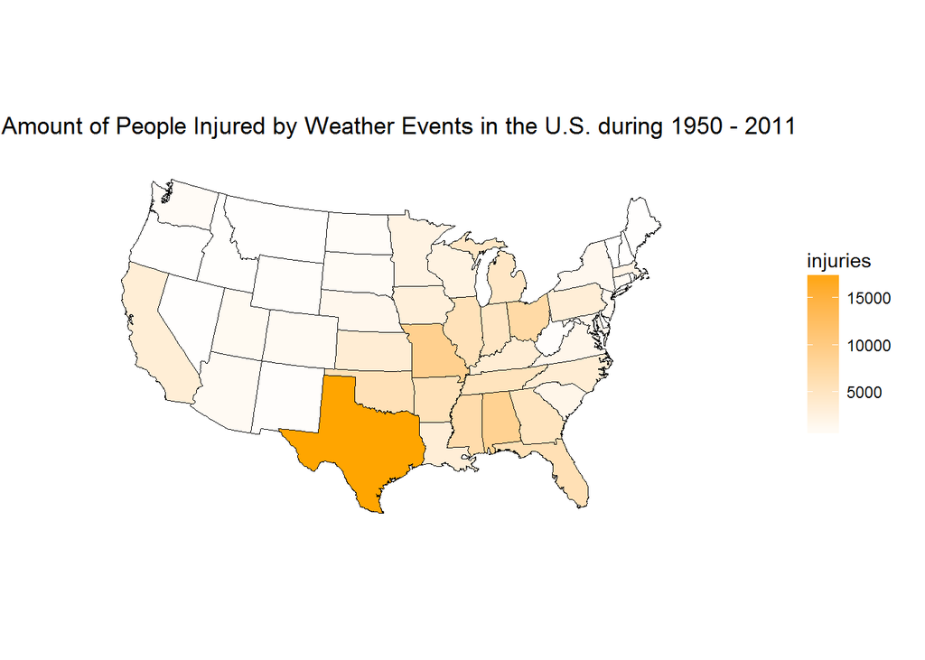

```r
# Plot the Amount of People Injured by Weather Events in the U.S. during
# 1950 - 2011
us <- map_data("state")

gg <- ggplot() + geom_map(data = us, map = us, aes(x = long, y = lat, map_id = region),
    fill = "white", color = "black", size = 0.15) + geom_map(data = injuries,
    map = us, aes(fill = injuries, map_id = tolower(region)), color = "black",
    size = 0.15) + scale_fill_continuous(low = "white", high = "orange", guide = "colorbar") +
    ggtitle("Amount of People Injured by Weather Events in the U.S. during 1950 - 2011") +
    labs(x = NULL, y = NULL) + coord_map("albers", lat0 = 39, lat1 = 45) + theme(panel.border = element_blank()) +
    theme(panel.background = element_blank()) + theme(axis.ticks = element_blank()) +
    theme(axis.text = element_blank())
gg
```

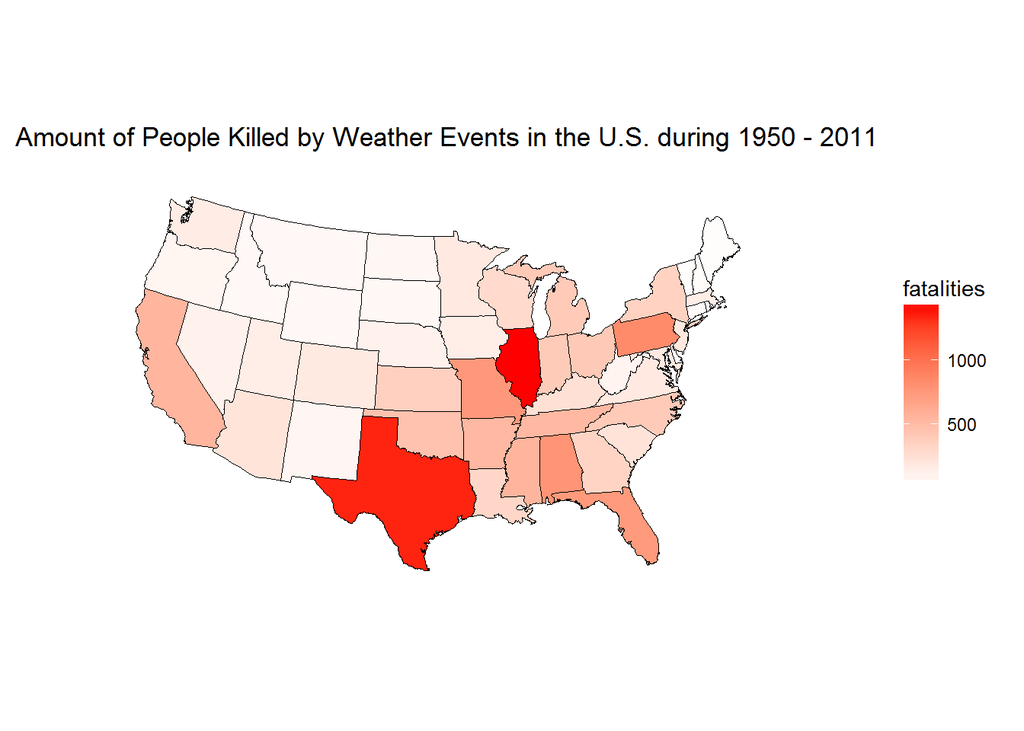

```r
# Plot the Amount of People Killed by Weather Events in the U.S. during 1950
# - 2011
gg2 <- ggplot() + geom_map(data = us, map = us, aes(x = long, y = lat, map_id = region),
    fill = "white", color = "black", size = 0.15) + geom_map(data = fatalities,
    map = us, aes(fill = fatalities, map_id = tolower(region)), color = "black",
    size = 0.15) + scale_fill_continuous(low = "white", high = "red", guide = "colorbar") +
    ggtitle("Amount of People Killed by Weather Events in the U.S. during 1950 - 2011") +
    labs(x = NULL, y = NULL) + coord_map("albers", lat0 = 39, lat1 = 45) + theme(panel.border = element_blank()) +
    theme(panel.background = element_blank()) + theme(axis.ticks = element_blank()) +
    theme(axis.text = element_blank())
gg2
```

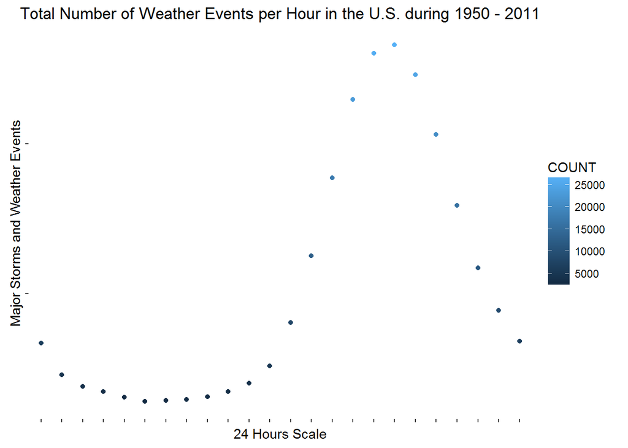

```r
# Plot the Total Number of Weather Events per Hour in the U.S. during 1950 -
# 2011
rawTimeData <- subset(rawData, select = c("BGN_TIME"))
rawTimeData$BGN_TIME <- sapply(rawTimeData$BGN_TIME, FUN = function(x) {
    if (nchar(as.character(x)) > 4)
        return(strftime(strptime(x, format = "%H:%M:%S %r"), format = "%H")) else return(strftime(strptime(x, format = "%H%M"), format = "%H"))
})

timeData <- ddply(rawTimeData, "BGN_TIME", summarise, COUNT = length(BGN_TIME))
timeData <- timeData[complete.cases(timeData), ]
rushHour <- max(timeData$COUNT)

p1 <- qplot(BGN_TIME, COUNT, data = timeData, geom = "point", fill = COUNT,
    color = COUNT) + ggtitle("Total Number of Weather Events per Hour in the U.S. during 1950 - 2011") +
    labs(x = "24 Hours Scale", y = "Major Storms and Weather Events") + theme(panel.border = element_blank()) +
    theme(panel.background = element_blank()) + theme(axis.text = element_blank())
p1
```

## Results

This study has demonstrated the threats bue to major storms and severe weather events in the United States of America.